## **SHOW3**

Hoje foi um dia de alta para o mercado, e alguns ativos se destacaram especialmente. O SHOW3, por exemplo, surpreendeu todos com uma variação de 12,4% no seu fechamento diário. Isso significa que as expectativas dos investidores foram mais do que cumpridas, fazendo com que a ação suba drasticamente, alcançando um valor de R$7,00 ao fechar.Para entender melhor o que está acontecendo, é preciso olhar para o histórico da ação. No mês passado, o SHOW3 registrou uma variação de 945%, e no trimestre, foi de 900%. Isso significa que os investidores estão muito otimistas sobre a empresa e sua capacidade de crescer. Além disso, a variação anual também é impressionante, com um crescimento de 914% em apenas um ano.Outro fator importante é o volume negociado. Hoje, houve um aumento significativo no volume, de 389% em relação ao dia anterior. Isso pode indicar que os investidores estão se juntando à festa e comprando a ação em grandes quantidades.Em resumo, o SHOW3 teve um dia incrível, com uma variação de 12,4% no seu fechamento diário. Essa performance é impressionante, especialmente quando consideramos as variações históricas da ação. É claro que é importante lembrar que o mercado é sempre volátil e que os preços podem variar rapidamente. Mas para agora, o SHOW3 está em alta e parece ter todo o potencial de continuar crescendo. Veja a seguir o gráfico do desempenho ao longo do tempo.

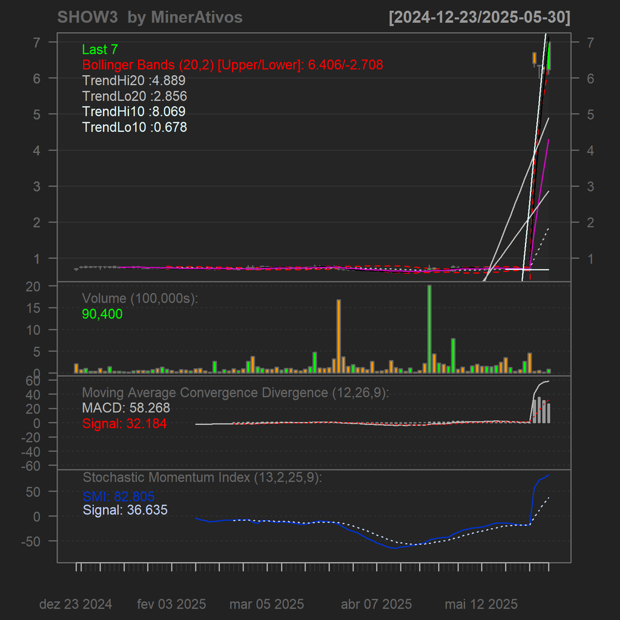

[figure not shown]